# Lab 1 - Parte 3: Suas Perguntas

Luiz Fonseca

16 de novembro de 2016

Primeiro vamos carregar os dados e bibliotecas que serão utilizados.

```r
# library(dplyr)
# library(ggplot2)
# library(scales)
# library(reshape2)

alunos_ufcg <- read.csv("../data/alunosUFCGAnon.csv")
```

## Atividade 1

### Perguntas

1. Para o curso de Ciência da Computação do campus 1, de uma forma geral, as notas aumentam ou diminuem ao longo do curso?
2. Como estão distribuídas as notas dos alunos nos diferentes turnos: matutino, vespertino, diurno e noturno?
3. É grande (ou pequena) a porcentagem de alunos que trancou ou reprovou uma disciplina optativa e depois voltou a se matricular na mesma disciplina? Em qual curso isso mais ocorre?

### Respostas antes da análise

1. Eu acho que as notas aumentam ao longo do curso por alguns motivos. O primeiro é que no começo do curso geralmente os estudantes estão desacostumados com o ritmo de estudo do Ensino Superior, que é mais desgastante do que o ritmo do Ensino Médio. O segundo motivo é que conforme os alunos vão avançando no curso, acho que o sentimento de competitividade vai aumentando e faz os alunos se esforçarem mais. Outro motivo que acho é que conforme os alunos vão se engajando no mundo da computação, as disciplinas se tornam mais interessantes e mais fáceis de aprender, até porque depois de um tempo o aluno já deve ter aprendido tecnologias que o auxiliarão nas disciplinas mais adiante.
2. Acho que os cursos de um único turno podem possuir notas mais altas do que os cursos diurnos (manhã e tarde) e dentre os cursos de único turno, acho que o da noite deve possuir notas mais baixas. Eu considero que os cursos que ocorrem em dois turnos são mais difíceis e mais estressantes, além de que o estudante terá menos tempo para estudar em casa e fazer atividades lúdicas para desestressar. Acho que o turno da noite possui notas mais baixas em comparação com os outros turnos únicos porque é um período mais cansativo, por ser no final do dia.
3. Eu acho que essa porcentagem deva ser menor que 50%. Isso porque se um aluno se der mal em uma disciplina que não é obrigatória, provavelmente, ele não irá querer cursá-la novamente por conta da sua experiência anterior ruim.

## Atividade 2

As perguntas que escolhi responder foram 1 e 2.

#### Pergunta 1

**Para o curso de Ciência da Computação do campus 1, de uma forma geral, as notas aumentam ou diminuem ao longo do curso?**

```r
alunos_computacao <- alunos_ufcg %>% filter(Nome_Curso == "CIÊNCIA DA COMPUTAÇÃO - D")

media_alunos_por_periodo <- alunos_computacao %>%
  group_by(Matricula) %>%
  mutate(Total_Periodos = max(Periodo_Relativo)) %>%
  filter(Total_Periodos >= 8 & Total_Periodos <= 16) %>%
  group_by(Matricula, Periodo_Relativo) %>%
  summarise(Media_Periodo = round(weighted.mean(Media_Disciplina, Creditos, na.rm = TRUE), 2)) %>%
  arrange(Matricula, Periodo_Relativo) %>%
  ungroup() %>%
  group_by(Matricula) %>%
  mutate(Evolucao_Media = ifelse(Media_Periodo > lag(Media_Periodo),
                                 "aumentou",
                                 ifelse(Media_Periodo == lag(Media_Periodo),
                                        "igual",
                                        "diminuiu")))

evolucao_por_periodo <- media_alunos_por_periodo %>%
  group_by(Periodo_Relativo) %>%
  summarise(total_aumentou = sum(Evolucao_Media == "aumentou", na.rm = TRUE),
            total_igual = sum(Evolucao_Media == "igual", na.rm = TRUE),
            total_diminuiu = sum(Evolucao_Media == "diminuiu", na.rm = TRUE)) %>%
  filter(Periodo_Relativo != 1)

evolucao_por_periodo$total_alunos = evolucao_por_periodo$total_aumentou +
  evolucao_por_periodo$total_igual + evolucao_por_periodo$total_diminuiu

evolucao_por_periodo <- evolucao_por_periodo %>%
  mutate(perc_aumentou = round(total_aumentou / total_alunos, 3) * 100,
         perc_igual = round(total_igual / total_alunos, 3)  * 100,
         perc_diminuiu = round(total_diminuiu / total_alunos, 3)  * 100) %>%
  select(-total_alunos, -total_aumentou, -total_igual, -total_diminuiu)

evolucao_melted <- melt(cbind(evolucao_por_periodo, periodo = as.numeric(rownames(evolucao_por_periodo)) + 1), id.vars = c('periodo'), c(2,3,4))
```

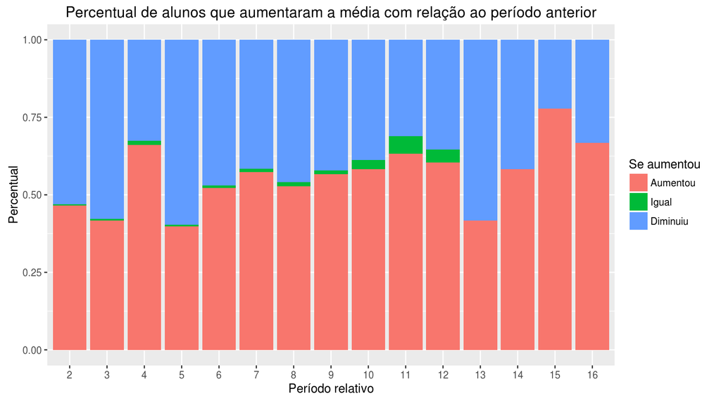

A partir do gráfico podemos perceber que a diferença entre as porcentagens não é gritante e então não podemos afirmar que a média aumenta ou diminui com o decorrer do curso.

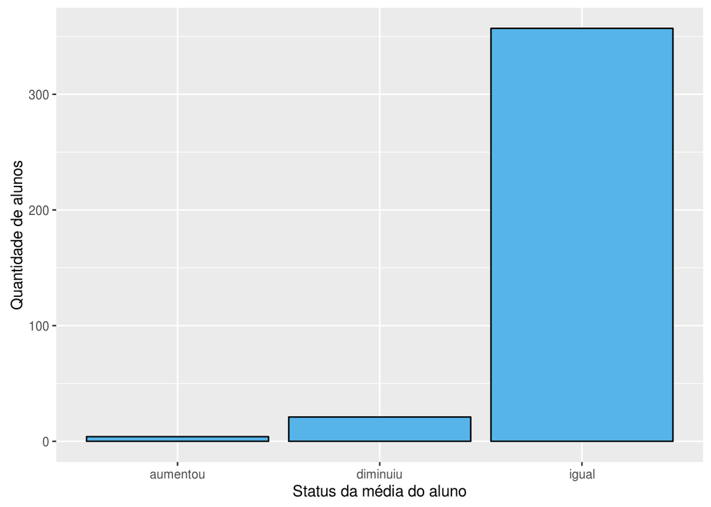

```r
media_final_alunos <- media_alunos_por_periodo %>%
  group_by(Matricula) %>%
  summarise(Media_Total_Final = mean(Media_Periodo),
            Media_primeiro_periodo = head(Media_Periodo, 1)) %>%
  mutate(Evolucao_Curso = ifelse(Media_primeiro_periodo - Media_Total_Final >= 2,
                                 "diminuiu",
                                 ifelse(Media_primeiro_periodo - Media_Total_Final <= -2,
                                        "aumentou",
                                        "igual")))

avaliacao_geral_alunos <- as.data.frame(table(media_final_alunos$Evolucao_Curso))

ggplot(avaliacao_geral_alunos, aes(x = Var1, y = Freq)) +
  geom_bar(stat="identity", fill="#56B4E9", colour="black") +
  labs(x = "Status da média do aluno", y = "Quantidade de alunos")
```

#### Pergunta 2

**Como estão distribuídas as notas dos alunos nos diferentes turnos: matutino, vespertino, diurno e noturno?**

Para responder essa pergunta, utilizarei um boxplot para cada turno para termos uma noção da distribuição das notas por turno.

```r
get_turno <- function(nome_curso) {
  turno <- substring(nome_curso, nchar(nome_curso))
  return(
    ifelse(turno == "A" | turno == "D", "Diurno",
           ifelse(turno == "N", "Noturno",
                  ifelse(turno == "M", "Matutino", "Vespertino")))
  )
}

alunos_ufcg$Turno_Curso = get_turno(as.character(alunos_ufcg$Nome_Curso))
```

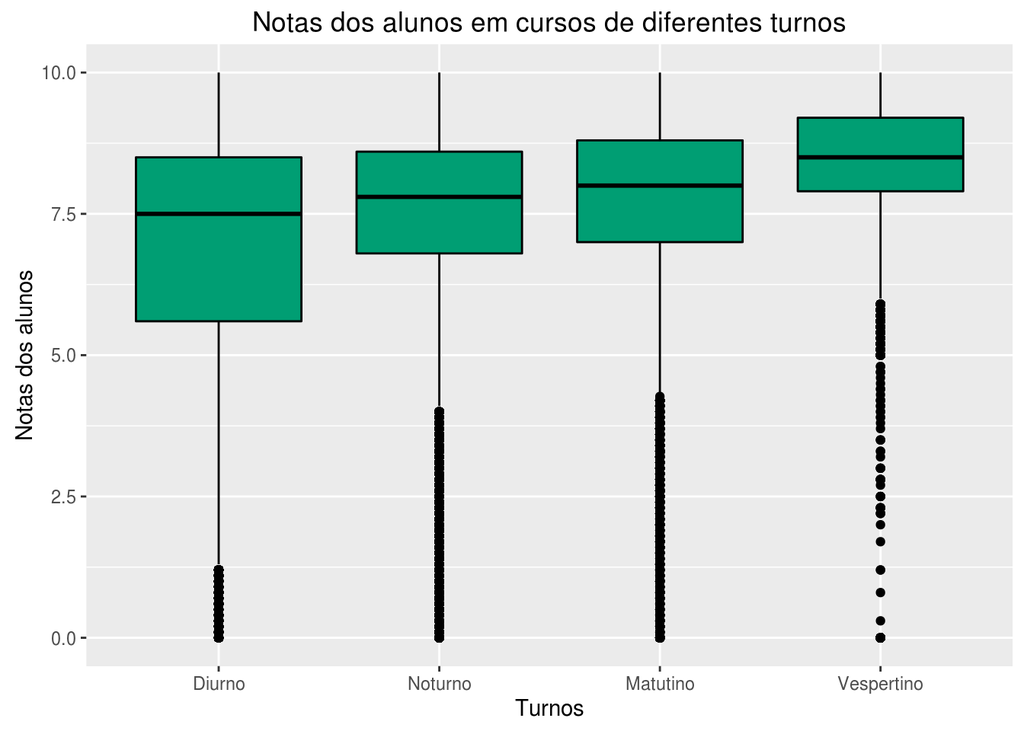

Como é mostrado no gráfico, os cursos com turno diurno possuem a menor mediana e o menor 1º quartil com relação aos demais turnos e dentre os cursos de único turno (manhã ou tarde ou noite) o turno noturno é o que apresenta a menor mediana e o menor primeiro quartil, isto é, as menores notas. Algumas hipóteses que poderiam explicar isto foram respondidas na Atividade 1.